# Detect Spam Emails

## Importing Needed Libraries

```python
import pandas as pd  #converts our data into dataframe
import numpy as np  # for numerical operations
import matplotlib.pyplot as plt #for data visualizations
import seaborn as sns  #for data visualizations
import string  #bc our data is categorical data
```

## Loading Dataset

```python
#using latin-1 encoding to handle special characters, and to avoid unicodeerror
df = pd.read_csv(r"C:\MLprojs\DetectSpamEmails\spam.csv", encoding='latin-1')
```

```python
df
```

|  | v1 | v2 | Unnamed: 2 | Unnamed: 3 | Unnamed: 4 |
| --- | --- | --- | --- | --- | --- |
| 0 | ham | Go until jurong point, crazy.. Available only ... | NaN | NaN | NaN |
| 1 | ham | Ok lar... Joking wif u oni... | NaN | NaN | NaN |
| 2 | spam | Free entry in 2 a wkly comp to win FA Cup fina... | NaN | NaN | NaN |
| 3 | ham | U dun say so early hor... U c already then say... | NaN | NaN | NaN |
| 4 | ham | Nah I don't think he goes to usf, he lives aro... | NaN | NaN | NaN |
| ... | ... | ... | ... | ... | ... |
| 5567 | spam | This is the 2nd time we have tried 2 contact u... | NaN | NaN | NaN |
| 5568 | ham | Will Ì_ b going to esplanade fr home? | NaN | NaN | NaN |
| 5569 | ham | Pity, * was in mood for that. So...any other s... | NaN | NaN | NaN |
| 5570 | ham | The guy did some bitching but I acted like i'd... | NaN | NaN | NaN |
| 5571 | ham | Rofl. Its true to its name | NaN | NaN | NaN |

5572 rows × 5 columns

our data has 5572 rows and 5 columns . 3 useless columns that we need to drop.

## Exploratory Data Analysis

```python
df.shape
```

```
(5572, 5)
```

5572 rows and 5 columns

```python
df.columns.tolist()
```

```
['v1', 'v2', 'Unnamed: 2', 'Unnamed: 3', 'Unnamed: 4']
```

our columns are: 'v1', 'v2' which don't refer to anything, so we need to rename them to :'label' and 'message', and some noisy columns :'Unnamed: 2', 'Unnamed: 3', 'Unnamed: 4' , we need to drop them.

```python
df.head()
```

|  | v1 | v2 | Unnamed: 2 | Unnamed: 3 | Unnamed: 4 |
| --- | --- | --- | --- | --- | --- |
| 0 | ham | Go until jurong point, crazy.. Available only ... | NaN | NaN | NaN |
| 1 | ham | Ok lar... Joking wif u oni... | NaN | NaN | NaN |
| 2 | spam | Free entry in 2 a wkly comp to win FA Cup fina... | NaN | NaN | NaN |
| 3 | ham | U dun say so early hor... U c already then say... | NaN | NaN | NaN |
| 4 | ham | Nah I don't think he goes to usf, he lives aro... | NaN | NaN | NaN |

```python
df.tail()
```

|  | v1 | v2 | Unnamed: 2 | Unnamed: 3 | Unnamed: 4 |
| --- | --- | --- | --- | --- | --- |
| 5567 | spam | This is the 2nd time we have tried 2 contact u... | NaN | NaN | NaN |
| 5568 | ham | Will Ì_ b going to esplanade fr home? | NaN | NaN | NaN |
| 5569 | ham | Pity, * was in mood for that. So...any other s... | NaN | NaN | NaN |
| 5570 | ham | The guy did some bitching but I acted like i'd... | NaN | NaN | NaN |
| 5571 | ham | Rofl. Its true to its name | NaN | NaN | NaN |

```python
df.sample(5)
```

|  | v1 | v2 | Unnamed: 2 | Unnamed: 3 | Unnamed: 4 |
| --- | --- | --- | --- | --- | --- |
| 158 | spam | Customer service annoncement. You have a New Y... | NaN | NaN | NaN |
| 1317 | spam | Win the newest ÛÏHarry Potter and the Order o... | NaN | NaN | NaN |
| 1866 | ham | Or Ì_ go buy wif him then i meet Ì_ later can? | NaN | NaN | NaN |
| 2252 | ham | Den wat will e schedule b lk on sun? | NaN | NaN | NaN |
| 4367 | ham | 1 I don't have her number and 2 its gonna be a... | NaN | NaN | NaN |

```python
df.info()
```

```
<class 'pandas.core.frame.DataFrame'>
RangeIndex: 5572 entries, 0 to 5571
Data columns (total 5 columns):
 #   Column      Non-Null Count  Dtype
---  ------      --------------  -----
 0   v1          5572 non-null   object
 1   v2          5572 non-null   object
 2   Unnamed: 2  50 non-null     object
 3   Unnamed: 3  12 non-null     object
 4   Unnamed: 4  6 non-null      object
dtypes: object(5)
memory usage: 217.8+ KB
```

summary of our dataset : v1 and v2 columns have 5572 non-null values out of 5572 , which means they are clean. Unnamed 2,3 and 4 columns have 50,12 and 6 non-null values out of 5572, which means they’re mostly empty and need to be dropped.

```python
df.describe()
```

|  | v1 | v2 | Unnamed: 2 | Unnamed: 3 | Unnamed: 4 |
| --- | --- | --- | --- | --- | --- |
| count | 5572 | 5572 | 50 | 12 | 6 |
| unique | 2 | 5169 | 43 | 10 | 5 |
| top | ham | Sorry, I'll call later | bt not his girlfrnd... G o o d n i g h t . . .@" | MK17 92H. 450Ppw 16" | GNT:-)" |
| freq | 4825 | 30 | 3 | 2 | 2 |

v1 column : has 5572 values , only 2 items are unique (spam and ham), ham is the most frequent and has been repeated 4825 times, which means that most of the emails are ham. v2 column : has 5572 values , 5169 items are unique , which means there are 403 repeated values, “Sorry, I’ll call later” is mostly repeated and has been repeated 30 times. (ignoring the three unnamed columns since we won’t need them anyways)

```python
df.isna().sum()
```

```
v1               0
v2               0
Unnamed: 2    5522
Unnamed: 3    5560
Unnamed: 4    5566
dtype: int64
```

```python
df.nunique()
```

```
v1               2
v2            5169
Unnamed: 2      43
Unnamed: 3      10
Unnamed: 4       5
dtype: int64
```

2 unique values in column v1, 5169 unique values in column v2

```python
df.duplicated().sum()
```

```
np.int64(403)
```

There are 403 repeated values in our dataset, as we saw before in v2 column ,that need to be removed

### Data cleaning

```python
#dropping duplicates
df= df.drop_duplicates()
```

```python
df.duplicated().sum()
```

```
np.int64(0)
```

now our data is clean from repeated values

```python
# dropping the three noisy columns
df=df.drop(columns=['Unnamed: 2','Unnamed: 3','Unnamed: 4'])
```

```python
#rechecking our null values
df.isna().sum()
```

```
v1    0
v2    0
dtype: int64
```

```python
#renaming v1 and v2 to meaningful names: label and message
df=df.rename(columns={'v1':'label' ,
                      'v2':'message'})
```

```python
df
```

|  | label | message |
| --- | --- | --- |
| 0 | ham | Go until jurong point, crazy.. Available only ... |
| 1 | ham | Ok lar... Joking wif u oni... |
| 2 | spam | Free entry in 2 a wkly comp to win FA Cup fina... |
| 3 | ham | U dun say so early hor... U c already then say... |
| 4 | ham | Nah I don't think he goes to usf, he lives aro... |
| ... | ... | ... |
| 5567 | spam | This is the 2nd time we have tried 2 contact u... |
| 5568 | ham | Will Ì_ b going to esplanade fr home? |
| 5569 | ham | Pity, * was in mood for that. So...any other s... |
| 5570 | ham | The guy did some bitching but I acted like i'd... |
| 5571 | ham | Rofl. Its true to its name |

5169 rows × 2 columns

#### Text Preprocessing & Cleaning

```python
#converting txt into lowercase
df['clean_msg'] = df['message'].apply(lambda s: s.lower())
```

```python
#removing punctuation
df['clean_msg'] = df['clean_msg'].apply(lambda s: s.translate(str.maketrans('', '',string.punctuation)))
```

```python
#importing Regular Expressions to remove numbers
import re
def removeNums(msg):
    return re.sub(r'\d+', '', msg) #any digit 0-9 one or more
df['clean_msg'] = df['clean_msg'].apply(removeNums)
df.head()
```

|  | label | message | clean_msg |
| --- | --- | --- | --- |
| 0 | ham | Go until jurong point, crazy.. Available only ... | go until jurong point crazy available only in ... |
| 1 | ham | Ok lar... Joking wif u oni... | ok lar joking wif u oni |
| 2 | spam | Free entry in 2 a wkly comp to win FA Cup fina... | free entry in a wkly comp to win fa cup final... |
| 3 | ham | U dun say so early hor... U c already then say... | u dun say so early hor u c already then say |
| 4 | ham | Nah I don't think he goes to usf, he lives aro... | nah i dont think he goes to usf he lives aroun... |

```python
#importing Natural Language Toolkit to remove stopwords
import nltk
nltk.download('stopwords')
from nltk.corpus import stopwords #corpus: a large collection of text

print(stopwords.words('english')[:20])
```

```
['a', 'about', 'above', 'after', 'again', 'against', 'ain', 'all', 'am', 'an', 'and', 'any', 'are', 'aren', "aren't", 'as', 'at', 'be', 'because', 'been']
```

```python
def removeStopwords (msg):
    words = msg.split()
    clean = []
    for word in words:
        if word not in stopwords.words('english'):
            clean.append(word)
    return " ".join(clean)
```

```python
df['clean_msg'] = df['clean_msg'].apply(removeStopwords)
```

### Data Visualization

**Bar Chart**

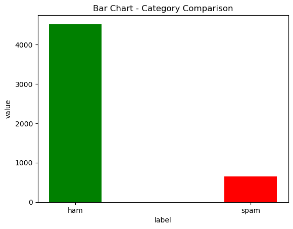

```python
categories = ["ham","spam"]
values =df['label'].value_counts()
plt.bar(categories, values, width=0.3,color=('green','red'))
plt.title('Bar Chart - Category Comparison' )
plt.xlabel('label')
plt.ylabel('value')
plt.show()
```

class imbalance

**Histogram:**

*comparing message length between spam and ham*

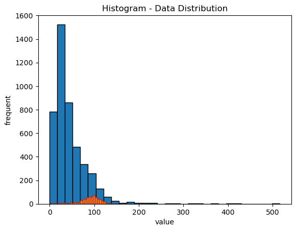

```python
df['msg_length']= df['clean_msg'].apply(len)
ham_msgs =df[df['label']=='ham']
spam_msgs =df[df['label']=='spam']
ham = ham_msgs['msg_length']
spam = spam_msgs['msg_length']

plt.hist(ham, bins=30,edgecolor="black")
plt.title('Histogram - Data Distribution')
plt.xlabel('value')
plt.ylabel('frequent')

plt.hist(spam, bins=30,edgecolor="brown")
plt.xlabel('value')
plt.ylabel('frequent')
plt.show()
```

Spam messages tend to be longer

**Wordcloud:**

*shows most frequent words in spam messages*

```python
from wordcloud import WordCloud
```

```python
spam_txt=" ".join(spam_msgs['clean_msg'])
```

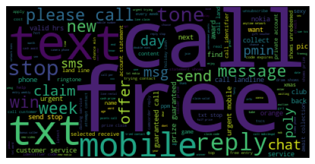

```python
wordCloud = WordCloud(min_word_length=3, random_state=42).generate(spam_txt)
plt.imshow(wordCloud)
plt.axis('off')
plt.show()
```

The most common words in spam messages are 'free', 'call', and 'text'

## Feature Engineering

**Converting our data into numerical features using TF-IDF**

### TF-IDF

```python
# importing TfidfVectorizer from sklearn.feature_extraction.text
# TF-IDF gives every word a number that represents how important it is
# TfidfVectorizer takes the raw txt and produces a matrix
from sklearn.feature_extraction.text import TfidfVectorizer
vectorizer = TfidfVectorizer()
X = vectorizer.fit_transform(df['clean_msg'])
print (X.shape)
```

```
(5169, 8449)
```

#### label encoding

```python
y=df['label'].map({'ham':0 , 'spam':1})
print (y.unique())
```

```
[0 1]
```

## Data spliting (Train/Test)

**Splitting data: 70% training and 30% testing**

```python
# importing train_test_split from sklearn.model_selection to train and test our model
from sklearn.model_selection import train_test_split
X_train , X_test, y_train , y_test = train_test_split(X, y , test_size=0.3 , random_state=42 )
```

```python
print(X_train.shape, X_test.shape)
```

```
(3618, 8449) (1551, 8449)
```

## Modeling

### Naive Bayes Model

```python
#importing our model
from sklearn.naive_bayes import MultinomialNB
from sklearn.metrics import accuracy_score , classification_report , confusion_matrix
```

```python
nb = MultinomialNB()
nb.fit(X_train , y_train)
y_pred_nb= nb.predict(X_test)
print ("NB Accuracy:  ", accuracy_score(y_test,y_pred_nb))
print("Classification Report:\n", classification_report(y_test,y_pred_nb))
print("Confusion Matrix:\n", confusion_matrix(y_test, y_pred_nb))
```

```
NB Accuracy:   0.9529335912314636
Classification Report:
               precision    recall  f1-score   support

           0       0.95      1.00      0.97      1331
           1       1.00      0.67      0.80       220

    accuracy                           0.95      1551
   macro avg       0.97      0.83      0.89      1551
weighted avg       0.96      0.95      0.95      1551

Confusion Matrix:
 [[1331    0]
 [  73  147]]
```

*achieved 95% accuracy*

### Logistic Regression Model

```python
# importing a sec model for comparison
from sklearn.linear_model import LogisticRegression
```

```python
model = LogisticRegression()
model.fit(X_train, y_train)
y_pred_lr = model.predict(X_test)
print("LG Accuracy:", accuracy_score(y_test, y_pred_lr))
print("Classification Report:\n", classification_report(y_test, y_pred_lr))
print("Confusion Matrix:\n", confusion_matrix(y_test, y_pred_lr))
```

```
LG Accuracy: 0.9329464861379755
Classification Report:
               precision    recall  f1-score   support

           0       0.93      0.99      0.96      1331
           1       0.95      0.56      0.70       220

    accuracy                           0.93      1551
   macro avg       0.94      0.78      0.83      1551
weighted avg       0.93      0.93      0.93      1551

Confusion Matrix:
 [[1324    7]
 [  97  123]]
```

*achieved 93% accuracy*

### Confusion Matrix

*table that summarizes the model’s performance by displaying the true positives (TP), false positives (FP), true negatives (TN), and false negatives (FN). It helps visualize how the model is performing in terms of the correct and incorrect predictions across all classes*

**Naive Bayes CM:**

```python
cm = confusion_matrix(y_test,y_pred_nb)
```

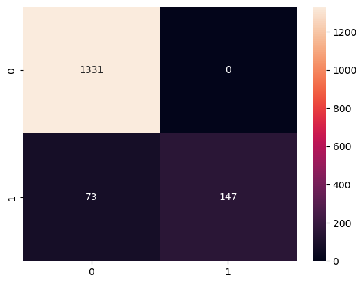

```python
sns.heatmap(cm, annot=True,fmt='d')
plt.show()
```

**1331:model said ham, actually was ham** / **0:model said spam, actually was ham**/ **73:model said ham, actually was spam.These are the missed spam messages**/ **147:model said spam, actually was spam**

**Logistic Regression CM:**

```python
cm = confusion_matrix(y_test,y_pred_lr)
```

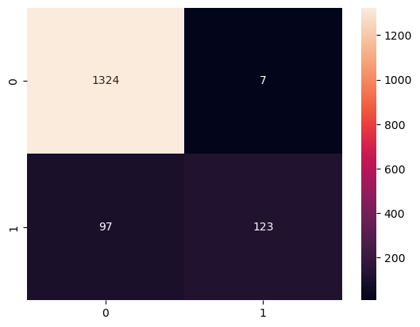

```python
sns.heatmap(cm, annot=True,fmt='d')
plt.show()
```

**1324:model said ham, actually was ham / 7:model said spam, actually was ham/ 97:model said ham, actually was spam.These are the missed spam messages/ 123:model said spam, actually was spam**

**so the Naive Bayes model is better as it was more accurate.**

### Saving the model

*saving the trained Naive Bayes model and TF-IDF vectorizer for deployment in the streamlit app*

```python
import pickle

with open('model.pkl', 'wb') as f:
    pickle.dump(nb, f)

with open('vectorizer.pkl', 'wb') as f:
    pickle.dump(vectorizer, f)
```